# Materials+ML Workshop Day 3

## Day 3 Agenda:

- Questions about Day 2 Material
- Review of Day 2

Content for today:

- Scientific Python Packages
  - Installing packages
- The NumPy package:
  - Numpy Arrays
  - Array Operations
  - Matrix and Vector Operations
- The SciPy package:
  - Scientific Constants
  - Integration
  - Optimization

## Background Survey

[figure not shown]

## https://forms.gle/FEWqPavJJYC9VzfH7

## The Workshop Online Book:

### https://cburdine.github.io/materials-ml-workshop/

## Tentative Workshop Schedule:

| Session | Date | Content |
| --- | --- | --- |
| Day 0 | 06/16/2023 (2:30-3:30 PM) | Introduction, Setting up your Python Notebook |
| Day 1 | 06/19/2023 (2:30-3:30 PM) | Python Data Types |
| Day 2 | 06/20/2023 (2:30-3:30 PM) | Python Functions and Classes |
| **Day 3** | **06/21/2023 (2:30-3:30 PM)** | **Scientific Computing with Numpy and Scipy** |
| Day 4 | 06/22/2023 (2:30-3:30 PM) | Data Manipulation and Visualization |
| Day 5 | 06/23/2023 (2:30-3:30 PM) | Materials Science Packages |
| Day 6 | 06/26/2023 (2:30-3:30 PM) | Introduction to ML, Supervised Learning |
| Day 7 | 06/27/2023 (2:30-3:30 PM) | Regression Models |
| Day 8 | 06/28/2023 (2:30-3:30 PM) | Unsupervised Learning |
| Day 9 | 06/29/2023 (2:30-3:30 PM) | Neural Networks |
| Day 10 | 06/30/2023 (2:30-3:30 PM) | Advanced Applications in Materials Science |

# Questions

Material covered yesterday:

- Python Functions
- Python Classes

## Review: Functions

- Python functions are reusable blocks of code that we can execute when it is called.
- Similar to mathamatical functions, Python functions can have inputs, outputs, or even modify variables

```python
# create a function to add two numbers:
def add_numbers(a,b):
    total = a + b
    return total # <-- output of function

# call `add_numbers` and store the output:
result = add_numbers(3,5)

print(result)
```

```
8
```

- Functions can also have default values:

```python
def greet(name, message="Hello"):
    """ Prints a greeting with a name and a message """
    print(message + ', ' + name + '!')

# call greet with the default message:
greet('Albert')

# call greet with a non-default message:
greet('Albert', 'Greetings')
```

```
Hello, Albert!
Greetings, Albert!
```

## Python Classes

- Python classes serve as a kind of "blueprint" for a data type
- Instances of classes we create are called *objects*

```python
class Dog:
    """ This class represents a pet dog """

    def __init__(self, dog_name):
        """ Constructs a Dog instance with given name """
        self.name = dog_name

    def bark(self):
        """ Causes this dog to bark """
        print(self.name + ' says: "Woof!"')
```

## Methods

- Methods are functions defined within the class body
- They have *self* as the first parameter, which allows for the method to be called using `object.function(...)` syntax
- Classes have a special `__init__` method called the *constructor*:
  - It is used for creating instances of a class
  - It is called by using the name of the class

```python
# construct a Dog object:
my_dog = Dog('Snoopy')

# change the `name` instance variable:
my_dog.name = 'Fido'

# call the bark() method:
my_dog.bark()
```

```
Fido says: "Woof!"
```

## New Content:

- Installing and Importing Python Packages
- Scientific Python packages
  - NumPy ("Numerical Python")
  - SciPy ("Scientific Python")

## Checking if Packages are installed

- The quickest way to check if a package is installed on your system is to import it:

```python
import numpy # import the NumPy base package
```

```python
import scipy # import the Scipy base package
```

- If either of these `import` statements results in an error, you will need to install the corresponding package.

## Installing Python Packages

If a package is not installed on your system, you can install it using `pip` (the package installer for Python) on your system:

```python
pip install numpy
```

```python
pip install scipy
```

- On some systems, you may need to invoke your command shell:

```python
!pip install numpy scipy
```

## Working with Packages

- When working with a package for the first time, it is helpful to read the package's online documentation
  - Numpy package: https://numpy.org/doc/stable/
  - Scipy package: https://docs.scipy.org/doc/scipy/

[figure not shown]

# The NumPy Package

- Numpy is a numerical computing package in Python
- Numpy provides an interface to several mathematical functions
- Numpy supports multi-dimensional arrays for fast numerical computing
  - These arrays are instances of the `numpy.ndarray` class
  - `ndarray`s can be used to represent vectors, matrices, tensors, etc.
- Common practice is to import `numpy` with the alias `np` at the beginning of a program:

```python
import numpy as np
```

## Mathematical functions:

- Numpy provides some basic mathematical functions and constants:

```python
# square root function:
print(np.sqrt(4))

# natural log and exponential functions:
print(np.log(10))
print(np.exp(-20))

# trigonometric functions (and pi constant)
print(np.sin(np.pi / 2))
```

```
2.0
2.302585092994046
2.061153622438558e-09
1.0
```

## Numpy arrays:

- Numpy arrays store an rectangular array of values of the same type (usually `float`, `int`, or `complex`)
- We create them from nested Python lists as follows:

```python
# create a 1D array:
x = np.array([1.0, 2.0, 3.0, 4.0])
print(x)

# create a 2D array (matrix):
X = np.array([
    [1,2,3],
    [4,5,6],
    [7,8,9]
])
print(X)
```

```
[1. 2. 3. 4.]
[[1 2 3]
 [4 5 6]
 [7 8 9]]
```

- Every array has an instance variable `shape`
- The length of the tuple is the dimension of the array
- The entries in the tuple represent the size of the array along each axis (i.e. dimension)

```python
# x is a 1D array of length 4:
print(x.shape)

# X is a 3x3 matrix:
print(X.shape)

# create an array of zeros with a 3x2x2 shape:
S = np.zeros((3,2,2))
print(S.shape)
```

```
(4,)
(3, 3)
(3, 2, 2)
```

## Reshaping Arrays:

```python
# print original shape of X:
print('X shape:', X.shape)

# reshape X to a 1D array:
X2 = X.reshape((9,))
print('\nX reshaped to (9,):')
print(X2)
print(X2.shape)

# reshape X to a 1x9 array:
X3 = X.reshape((1,9))
print('\nX reshaped to (1,9):')
print(X3)
print(X3.shape)
```

```
X shape: (3, 3)

X reshaped to (9,):
[1 2 3 4 5 6 7 8 9]
(9,)

X reshaped to (1,9):
[[1 2 3 4 5 6 7 8 9]]
(1, 9)
```

## Functions for Building Arrays:

```python
# construct a 3x3 identity (i.e. I or "eye") matrix:
print(np.eye(3))

# construct an array of ones:
print(np.ones((2,3)))

# construct an array of 11 equally spaced points from 0 to 1:
x = np.linspace(0.0, 1.0, 11)
print(x)

# construct an array of ones/zeros with the same shape as x:
x_ones = np.ones_like(x)
print(x_ones)
```

```
[[1. 0. 0.]
 [0. 1. 0.]
 [0. 0. 1.]]
[[1. 1. 1.]
 [1. 1. 1.]]
[0.  0.1 0.2 0.3 0.4 0.5 0.6 0.7 0.8 0.9 1. ]
[1. 1. 1. 1. 1. 1. 1. 1. 1. 1. 1.]
```

# Indexing Arrays

- Numpy arrays can be indexed like Python lists, but with some added features:
  - multiple indices can be selected using comma-separated indexes (e.g. `array[1,2,3]`)
  - The entire subarray along an index can be selected using `:` instead of an index

```python
X = np.array(range(1,10)).reshape((3,3))
print(X)

# access row 0:
print('\nAccessing X[0]:')
print(X[0])

# access row 0, column 2:
print('\nAccessing X[0,2]:')
print(X[0,2])

# access column 0:
print('\nAccessing X[:,0]:')
print(X[:,0])
```

```
[[1 2 3]
 [4 5 6]
 [7 8 9]]

Accessing X[0]:
[1 2 3]

Accessing X[0,2]:
3

Accessing X[:,0]:
[1 4 7]
```

## Operations on Numpy Arrays:

- All math operations on arrays are performed elementwise:

```python
x1 = np.array([1,2,3])
x2 = np.array([4,5,6])

# all math operations are elementwise:
print(x1 + x2)
print(x1 - x2)
print(x1 * x2)
print(np.sqrt(x1))

# scalar operations are also elementwise:
print('\nScalar operations:')
print(x1 - 1)
print(x1*2)
print(-x1)
```

```
[5 7 9]
[-3 -3 -3]
[ 4 10 18]
[1.         1.41421356 1.73205081]

Scalar operations:
[0 1 2]
[2 4 6]
[-1 -2 -3]
```

## Matrix Operations

- 1D array can be used to represent a vector,
- 2D arrays can be used to represent a matrix
- Numpy supports many different matrix and vector operations from the `linalg` package:

```python
# generate a matrix:
A = np.array(range(1,10)).reshape(3,3)
print(A)

# generate a diagonal matrix:
X = np.diag([1,10,100])
print(X)

# matrix transpose:
print(A.T)

# matrix inverse:
print(np.linalg.inv(X))
```

```
[[1 2 3]
 [4 5 6]
 [7 8 9]]
[[  1   0   0]
 [  0  10   0]
 [  0   0 100]]
[[1 4 7]
 [2 5 8]
 [3 6 9]]
[[1.   0.   0.  ]
 [0.   0.1  0.  ]
 [0.   0.   0.01]]
```

## Linear Algebra:

- Matrix-Matrix and Matrix-vector product can be computed using the reserved `@` operator:

```python
# compute a matrix-matrix product:
print('\nA @ X:')
print(A @ X)

# compute a matrix-vector product:
b = np.array([1,10,100])
print('\nA @ b:')
print(A @ b)

# compute a vector dot product (inner product):
print('\nb • b:')
print(np.dot(b,b))

# compute vector norm:
print('\n|b|:')
print(np.linalg.norm(b))
```

```
A @ X:
[[  1  20 300]
 [  4  50 600]
 [  7  80 900]]

A @ b:
[321 654 987]

b • b:
10101

|b|:
100.50373127401788
```

# The Scipy Package

- Scipy provides many useful subpackages for scientific computing
- Subpackages you may find useful include:
  - `scipy.constants`: physical constants, unit conversions
  - `scipy.optimize`: functions for optimization and root finding
  - `scipy.integrate`: functions numerical integration
  - `scipy.stats`: statistical analysis functions
  - `scipy.special`: special functions (e.g. Bessel functions, Ganna function, etc.)

## Scientific Constants

```python
from scipy import constants
```

```python
print(constants.pi)             # 3.141592653589793
print(constants.speed_of_light) # 299792458.0 [m/s]
print(constants.Avogadro)       # 6.02214076e+23 [mol^(-1)]
print(constants.G)              # Gravitational constant [m^3 / kg s^2 ]
print(constants.Boltzmann)      # Boltzmann constant [J/K]
print(constants.m_e)            # Electron mass [kg]
```

```
3.141592653589793
299792458.0
6.02214076e+23
6.6743e-11
1.380649e-23
9.1093837015e-31
```

## Integration

- We can integrate functions over a specific domain using [`scipy.integrate.quad`](https://docs.scipy.org/doc/scipy/reference/generated/scipy.integrate.quad.html#scipy-integrate-quad).
  - Example: integrating the Gaussian function:

  $$\int_{-\infty}^\infty e^{-x^2}\ dx = \sqrt{\pi}$$

```python
import numpy as np
from scipy.integrate import quad
```

```python
# Gaussian function:
def gauss(x):
    return np.exp(-x**2)

# integrate from -10^3 to +10^3 (close enough to infinity):
integral, error = quad(gauss, -1e3, 1e3)

# compare numerical result with actual result:
print(integral)
print(np.sqrt(np.pi))
```

```
1.7724538509055159
1.7724538509055159
```

## Optimization

- We can use the `scipy.optimize` subpackage to attempt to find the global or local minima of a Python function
- This package is also useful for fitting curves to data
  - See [`scipy.optimize.curve_fit`](https://docs.scipy.org/doc/scipy/reference/generated/scipy.optimize.curve_fit.html#scipy-optimize-curve-fit)

## Example Fitting linear data to a function:

- To test scipy's `curve_fit` function, let's create some linear data with a bit of random noise:

```python
import numpy as np
from scipy.optimize import curve_fit

# generate N datapoints that fit y = 10x + 3:
N = 10
x_data = np.linspace(0,10,N)
y_noise = np.random.normal(size=N)
y_data = 10*x_data + 3 + y_noise
```

```python
# linear model of the form y = ax + b:
def linear_model(x, a, b):
    return a*x + b

# fit the linear model to data:
initial_guess = (0,0)
p_opt, p_cov = curve_fit(linear_model,x_data, y_data, initial_guess)

# print the estimated a and b coefficients:
print('Estimated a:', p_opt[0], '(should be close to 10.0)')
print('Estimated b:', p_opt[1], '(should be close to 3.0)')
```

```
Estimated a: 9.969127086826829 (should be close to 10.0)
Estimated b: 2.9155794406611073 (should be close to 3.0)
```

## Visualize fit with Matplotlib

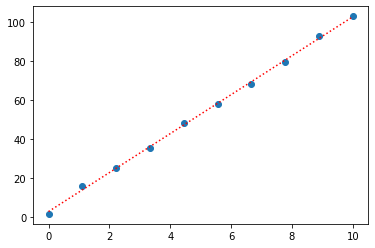

```python
import matplotlib.pyplot as plt

# evaluate best fit line at many points:
x_fit = np.linspace(0,10,1000)
y_fit = linear_model(x_fit, p_opt[0], p_opt[1])

# plot data and fitted line:
plt.figure()
plt.scatter(x_data,y_data)
plt.plot(x_fit, y_fit, 'r:')
plt.show()
```

## Special Functions:

- Special mathematical functions can be found in the `scipy.special` subpackage:
- Airy functions: `scipy.special.airy`
- Bessel functions: `scipy.special.jv`
- Spherical Bessel functions: `scipy.special.yn`
- Gamma function: `scipy.special.gamma`
- Rieman zeta function: `scipy.special.zeta`

## Recommended Reading:

- Data Handling and Visualization